# Example Project Task 2

Ben

2026-01-20

## Introduction

Consider the following general models:

- $f_0(L; a,b) = \frac{1}{b-a}$ with $-\infty < a < L < b < \infty$ (and 0 otherwise)
- $f_1(L; h,a) = \frac{1}{\sqrt{2\pi a}}e^{-\frac{(x-h)^2}{2a}}$ with $h > 0$, $a > 0$, and $-\infty < L < \infty$
- $f_2(L; h,a,b) = \frac{b^a}{\Gamma(a)}(L-h)^{a-1}e^{-b(L-h)}$ with $a > 0$, $b >0$, and $L \geq h$ (and 0 otherwise)

In this task, we will explore how the parameters above affect the graphs.

## The parameters for $f_0$

Parameter $a$ controls the left end of the domain of the function, while parameter b controls the right end of the domaion. The height of the function drops as $b-a$ increases. All of this can be seen in the two plots below.

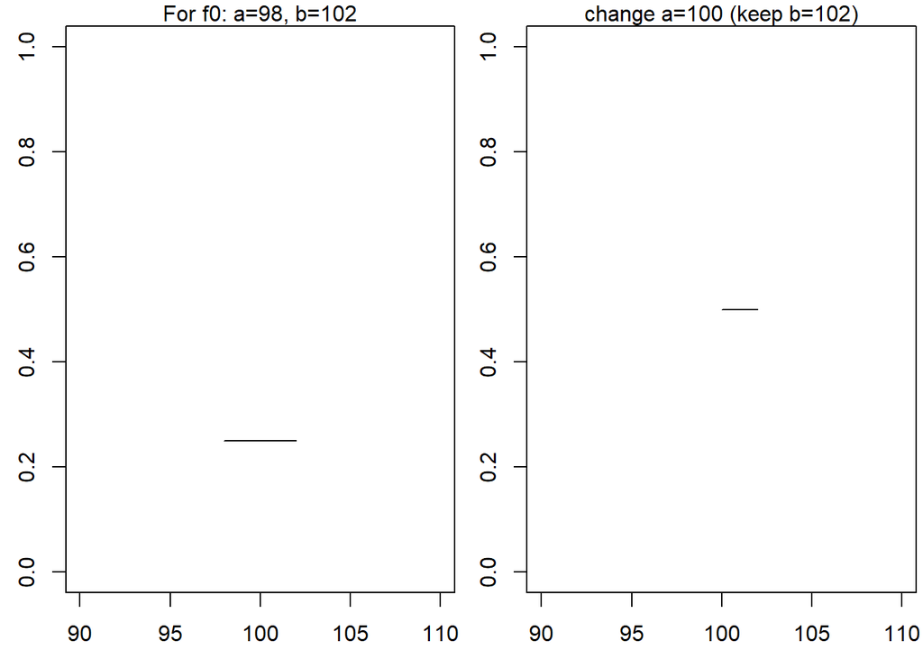

```r
f0 <- function(x,a=0,b=1){
  # Make sure a < b when using this function.
  ifelse(x < a,NaN, ifelse(x <= b, 1/(b-a), NaN))
}

a <- 98
b <- 102
x <- seq(a,b,0.1)
y <- f0(x,a,b)

par(mfrow=c(1,2),mar=c(2.5,2.5,1,0.25))
plot(x,y,type='l',xlim=c(90,110), ylim = c(0,1))
mtext('For f0: a=98, b=102', side = 3, line = 0)

a <- 100
x <- seq(a,b,0.1)
y <- f0(x,a,b)

plot(x,y,type='l',xlim=c(90,110), ylim = c(0,1))
mtext('change a=100 (keep b=102)', side = 3, line = 0)
```

The function is constant between $a$ and $b$. The closer the two values, the higher the graph.

## The parameters for $f_1$

For the function $f_1(L; h,a) = \frac{1}{\sqrt{2\pi a}}e^{-\frac{(x-h)^2}{2a}}$ with $h > 0$, $a > 0$, and $-\infty < L < \infty$, here is a description of how the parameters affect the plot.

In the graph below, we adjust $a$ from 1 to 5 (flattens the curve) and $h$ from 90 to 110 (center moves right).

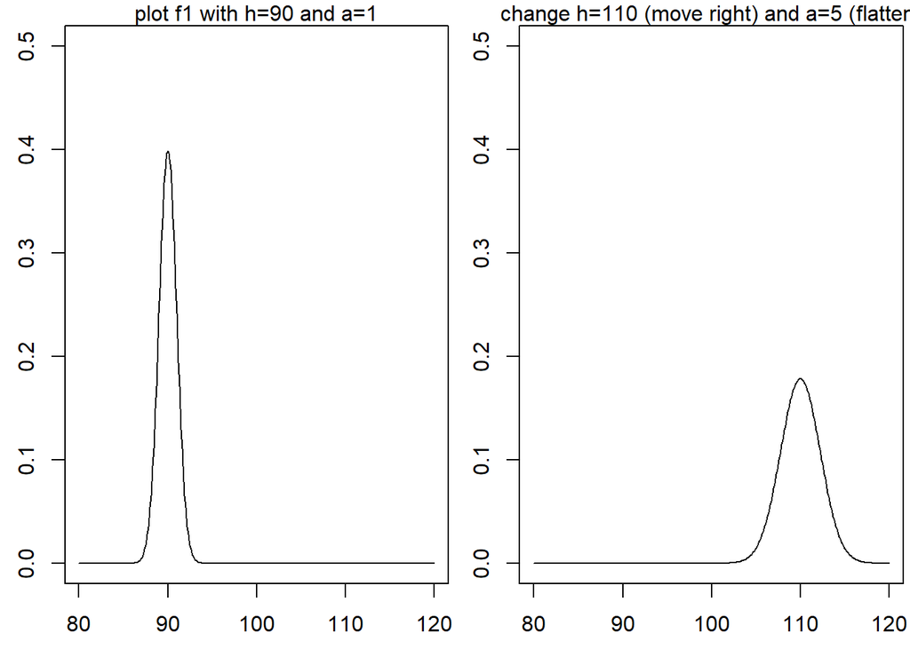

```r
f1 <- function(L,h=0,a=1){
  #Make sure h > 0 and a > 0.
  1/sqrt(2*pi*a)*exp(-(L-h)^2/(2*a))
}

a <- 1
L <- seq(80,120,0.1)
h <- 90
y <- f1(L,h,a)

par(mfrow=c(1,2),mar=c(2.5,2.5,1,0.25))
plot(L,y,type='l',xlim=c(80,120), ylim=c(0,0.5))
mtext('plot f1 with h=90 and a=1', side = 3, line = 0)

a <- 5
h <- 110
y <- f1(L,h,a)

plot(L,y,type='l',xlim=c(80,120), ylim=c(0,0.5))
mtext('change h=110 (move right) and a=5 (flatten)', side = 3, line = 0)
```

## The parameters for $f_2$ - The Gamma Distribution

We might not come back to this one and fully write up a solution. We will see this function appear again in Project 3.